# SVM Classification using Record Data

### Introduction

In this section, I will introduce the process of applying the Support Vector Machine (SVM) to record data classification, the dataset I use for SVM classfication, as well as the the classfication results. The code of using SVM classification on the record data will also be shown as a step by step process.

The record data I will be using for SVM classification is the country fertility rate dataset (FertilityRate_Clean.csv) that was cleaned and used in the previous sections, which can be found [here](https://github.com/anly501/anly-501-project-yeyaxin1103/tree/main/data/01-modified-data). The fertility rate dataset contains 10 attributes, which are Country Name, Country Code, year, Fertility Rate, Region, Income Group, GDP per Capita in USD, Human Development Index, Teritary School Enrollment Percentage, and labels. The labels of this dataset are binary that contain two classes: "Below Replacement" and "Above Replacement".

A snapshot of the dataset will be shown in the class distribution section below.

### What is Support Vector Machine (SVM)?

Support Vector Machines (SVM) are supervised learning models with associated learning algorithms, which can be used for both classification and regression analysis. SVM maps training examples to points in space so as to maximise the width of the gap between the two categories. New examples are then mapped into that same space and predicted to belong to a category based on which side of the gap they fall.

In addition to performing linear classification, SVMs can efficiently perform a non-linear classification using what is called the kernel trick, implicitly mapping their inputs into high-dimensional feature spaces. ([Source](https://en.wikipedia.org/wiki/Support_vector_machine))

The objective of the support vector machine algorithm is to find a hyperplane in an N-dimensional space(N — the number of features) that distinctly classifies the data points. Hyperplanes are decision boundaries that help classify the data points. Data points falling on either side of the hyperplane can be attributed to different classes. Also, the dimension of the hyperplane depends upon the number of features. If the number of input features is 2, then the hyperplane is just a line. If the number of input features is 3, then the hyperplane becomes a two-dimensional plane. It becomes difficult to imagine when the number of features exceeds 3. ([Source](https://towardsdatascience.com/support-vector-machine-introduction-to-machine-learning-algorithms-934a444fca47))

The advantages of support vector machines are:

- Effective in high dimensional spaces
- Still effective in cases where number of dimensions is greater than the number of samples
- Uses a subset of training points in the decision function (called support vectors), so it is also memory efficient
- Versatile: different Kernel functions can be specified for the decision function. Common kernels are provided, but it is also possible to specify custom kernels

The disadvantages of support vector machines include:

- If the number of features is much greater than the number of samples, avoid over-fitting in choosing Kernel functions and regularization term is crucial
- SVMs do not directly provide probability estimates, these are calculated using an expensive five-fold cross-validation ([Source](https://scikit-learn.org/stable/modules/svm.html))

Here are some visualizations of the SVM concept: [Source](https://towardsdatascience.com/support-vector-machine-introduction-to-machine-learning-algorithms-934a444fca47)

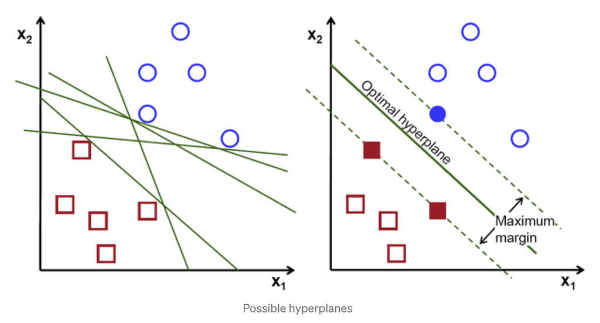

```python
from IPython.display import Image
Image(filename='img1.png')
```

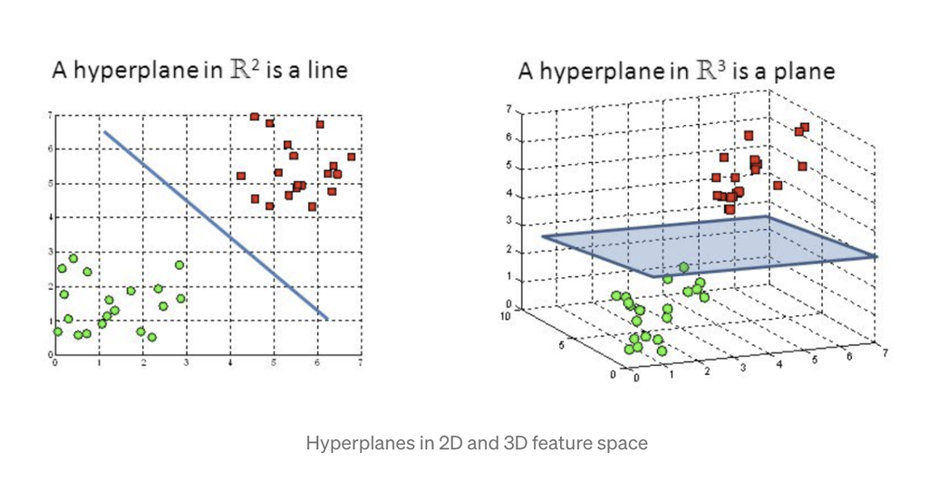

```python
Image(filename='img2.png')
```

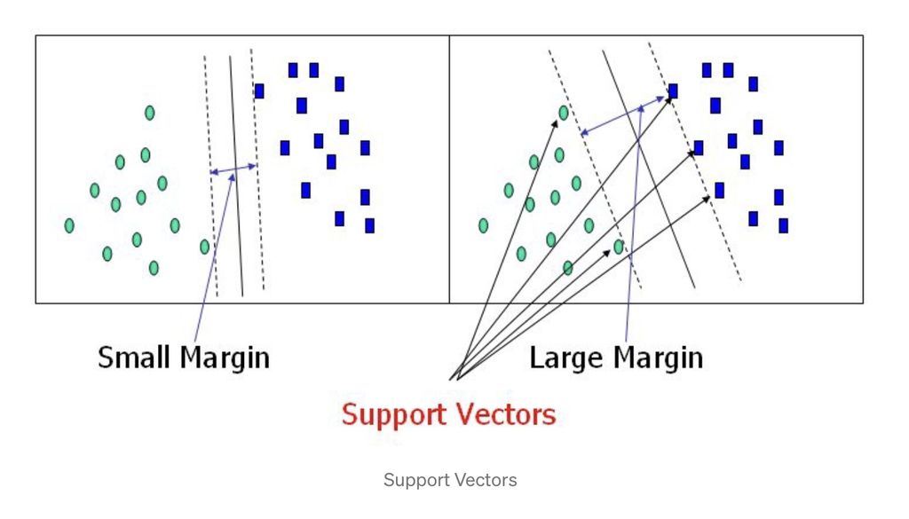

```python
Image(filename='img3.png')
```

### Class Distribution

Compute the distribution of class labels in the fertility dataset, since it might affect the classification algorithm results.

First, import necessary packages for performing the task.

```python
import pandas as pd
import numpy as np
from sklearn.metrics import accuracy_score
from sklearn.metrics import precision_score
from sklearn.metrics import recall_score
from sklearn.metrics import precision_recall_fscore_support
import random
from collections import Counter
```

A snapshot of the clean fertility rate dataset is shown below:

```python
#import dataset
df = pd.read_csv("../../data/01-modified-data/FertilityRate_Clean.csv")
df.head()
```

|  | Country_Name | Country_Code | year | FertilityRate | Region | IncomeGroup | GDPperCapita_USD | Human_Dev_Index | Tertiary_school_Enroll_Pctg | label |
| --- | --- | --- | --- | --- | --- | --- | --- | --- | --- | --- |
| 0 | Afghanistan | AFG | 1990 | 7.466 | South Asia | Low income | 287.200843 | 0.426556 | 2.211410 | Above Replacement |
| 1 | Afghanistan | AFG | 1991 | 7.479 | South Asia | Low income | 287.200843 | 0.426556 | 2.780193 | Above Replacement |
| 2 | Afghanistan | AFG | 1992 | 7.502 | South Asia | Low income | 287.200843 | 0.426556 | 2.780193 | Above Replacement |
| 3 | Afghanistan | AFG | 1993 | 7.535 | South Asia | Low income | 287.200843 | 0.426556 | 2.780193 | Above Replacement |
| 4 | Afghanistan | AFG | 1994 | 7.572 | South Asia | Low income | 287.200843 | 0.426556 | 2.780193 | Above Replacement |

```python
print('--------- Label Counts ---------\n', df['label'].value_counts())
print('-------- Label Percentage -------\n', (df['label'].value_counts())/df.shape[0])
```

```
--------- Label Counts ---------
 Above Replacement    3652
Below Replacement    2083
Name: label, dtype: int64
-------- Label Percentage -------
 Above Replacement    0.636792
Below Replacement    0.363208
Name: label, dtype: float64
```

**Interpretation:** Based on the label distribution results above, we can tell that the distribution of the two classes (Above Replacement & Below Replacement) is imbalanced, which might result in a relatively poor predictive performance of the model.

### Baseline Model for Comparison

In this part, I will run a random classifier on the fertility rate data and output accuracy, precision, and recall values in order to have a better preview of the possible classfication results using this dataset.

```python
def generate_label_data(class_labels, weights, N=10000):
    # e.g. class_labels=[0,1] weights=[0.2, 0.8] (should sum to one)

    y = random.choices(class_labels, weights = weights, k = N)
    print("-----GENERATING DATA-----")
    print("unique entries:",Counter(y).keys())
    print("count of labels:",Counter(y).values()) # counts the elements' frequency
    print("probability of labels:",np.fromiter(Counter(y).values(), dtype=float)/len(y)) # counts the elements' frequency
    return y


 ## RANDOM CLASSIFIER
def random_classifier(y_data):
    ypred=[]
    max_label=np.max(y_data); #print(max_label)
    for i in range(0,len(y_data)):
        ypred.append(int(np.floor((max_label+1)*np.random.uniform(0,1))))
    print("-----RANDOM CLASSIFIER-----")
    print("count of prediction:",Counter(ypred).values()) # counts the elements' frequency
    print("probability of prediction:",np.fromiter(Counter(ypred).values(), dtype=float)/len(y_data)) # counts the elements' frequency
    print("accuracy",accuracy_score(y_data, ypred))
    print("percision, recall, fscore,",precision_recall_fscore_support(y_data, ypred))
```

```python
# using random classifier on the Tweet text data based on the weights calculated above
print("--- Using Random Classifier on the Twitter Text Data ---\n")
y=generate_label_data([0,1],[0.636792,0.363208],df.shape[0])
random_classifier(y)
```

```
--- Using Random Classifier on the Twitter Text Data ---

-----GENERATING DATA-----
unique entries: dict_keys([0, 1])
count of labels: dict_values([3635, 2100])
probability of labels: [0.63382738 0.36617262]
-----RANDOM CLASSIFIER-----
count of prediction: dict_values([2869, 2866])
probability of prediction: [0.50026155 0.49973845]
accuracy 0.4993897122929381
percision, recall, fscore, (array([0.63328681, 0.36563262]), array([0.49931224, 0.49952381]), array([0.55837563, 0.42221775]), array([3635, 2100]))
```

**Interpretation:**

Based on the results generated by the random classifier above, we can see that the expected accuracy, precision, recall and fscore of using this data are not very high. Probabily due to to the inequal distribution of the labels/classes.

### Data Pre-Processing

1. Feature Selection: only keeping the attributes needed for the SVM, which are "IncomeGroup", "GDPperCapita_USD", "Human_Dev_Index", "Tertiary_school_Enroll_Pctg", and "label" columns in this case.

```python
df = df[["IncomeGroup", "GDPperCapita_USD", "Human_Dev_Index", "Tertiary_school_Enroll_Pctg", "label"]]
df.head()
```

|  | IncomeGroup | GDPperCapita_USD | Human_Dev_Index | Tertiary_school_Enroll_Pctg | label |
| --- | --- | --- | --- | --- | --- |
| 0 | Low income | 287.200843 | 0.426556 | 2.211410 | Above Replacement |
| 1 | Low income | 287.200843 | 0.426556 | 2.780193 | Above Replacement |
| 2 | Low income | 287.200843 | 0.426556 | 2.780193 | Above Replacement |
| 3 | Low income | 287.200843 | 0.426556 | 2.780193 | Above Replacement |
| 4 | Low income | 287.200843 | 0.426556 | 2.780193 | Above Replacement |

1. Replace non-numeric column values with numeric values.
- IncomeGroup: Unclassified -> -1, Low income -> 0, Lower middle income -> 1, Upper middle income -> 2, High income -> 3.

```python
df['IncomeGroup'].replace({'Unclassified' : -1, 'Low income' : 0, 'Lower middle income' : 1, 'Upper middle income' : 2, 'High income' : 3}, inplace=True)
df.head()
```

|  | IncomeGroup | GDPperCapita_USD | Human_Dev_Index | Tertiary_school_Enroll_Pctg | label |
| --- | --- | --- | --- | --- | --- |
| 0 | 0 | 287.200843 | 0.426556 | 2.211410 | Above Replacement |
| 1 | 0 | 287.200843 | 0.426556 | 2.780193 | Above Replacement |
| 2 | 0 | 287.200843 | 0.426556 | 2.780193 | Above Replacement |
| 3 | 0 | 287.200843 | 0.426556 | 2.780193 | Above Replacement |
| 4 | 0 | 287.200843 | 0.426556 | 2.780193 | Above Replacement |

```python
np.random.shuffle(df.values)
print(df.shape)
df.head()
```

```
(5735, 5)
```

|  | IncomeGroup | GDPperCapita_USD | Human_Dev_Index | Tertiary_school_Enroll_Pctg | label |
| --- | --- | --- | --- | --- | --- |
| 0 | 0 | 287.200843 | 0.426556 | 2.211410 | Above Replacement |
| 1 | 0 | 287.200843 | 0.426556 | 2.780193 | Above Replacement |
| 2 | 0 | 287.200843 | 0.426556 | 2.780193 | Above Replacement |
| 3 | 0 | 287.200843 | 0.426556 | 2.780193 | Above Replacement |
| 4 | 0 | 287.200843 | 0.426556 | 2.780193 | Above Replacement |

1. Divide data into X and y datasets.
- X: Columns other than label -> IncomeGroup, GDPperCapita_USD, Human_Dev_Index, Tertiary_school_Enroll_Pctg
- y: Column label

```python
X =  df.loc[:, df.columns != 'label']
y = df.loc[:, 'label']
print('Shape of X:', X.shape)
print('Shape of y:', y.shape)
```

```
Shape of X: (5735, 4)
Shape of y: (5735,)
```

1. Splitting Dataset into Training and Testing Data & Normalizing Data

```python
from sklearn.model_selection import train_test_split

X = (X - X.mean()) / X.std()

test_ratio = 0.2
x_train, x_test, y_train, y_test = train_test_split(X, y, test_size = test_ratio, random_state = 0)
y_train = y_train.squeeze()
y_test = y_test.squeeze()

print('X_train.shape		:', x_train.shape)
print('y_train.shape		:', y_train.shape)
print('X_test.shape		:', x_test.shape)
print('y_test.shape		:', y_test.shape)

print('x_train shape:', x_train.shape)
print('x_test shape:', x_test.shape)
print('y_train shape:', y_train.shape)
print('x_test shape:',y_test.shape)
print('\n----- levels of the dependent variable (Y) -----')
print(y.value_counts())
```

```
X_train.shape		: (4588, 4)
y_train.shape		: (4588,)
X_test.shape		: (1147, 4)
y_test.shape		: (1147,)
x_train shape: (4588, 4)
x_test shape: (1147, 4)
y_train shape: (4588,)
x_test shape: (1147,)

----- levels of the dependent variable (Y) -----
Above Replacement    3652
Below Replacement    2083
Name: label, dtype: int64
```

### Model Training: Support Vector Machine

Here are a few SVM models and their concept visualization ([Source](https://scikit-learn.org/stable/modules/svm.html)):

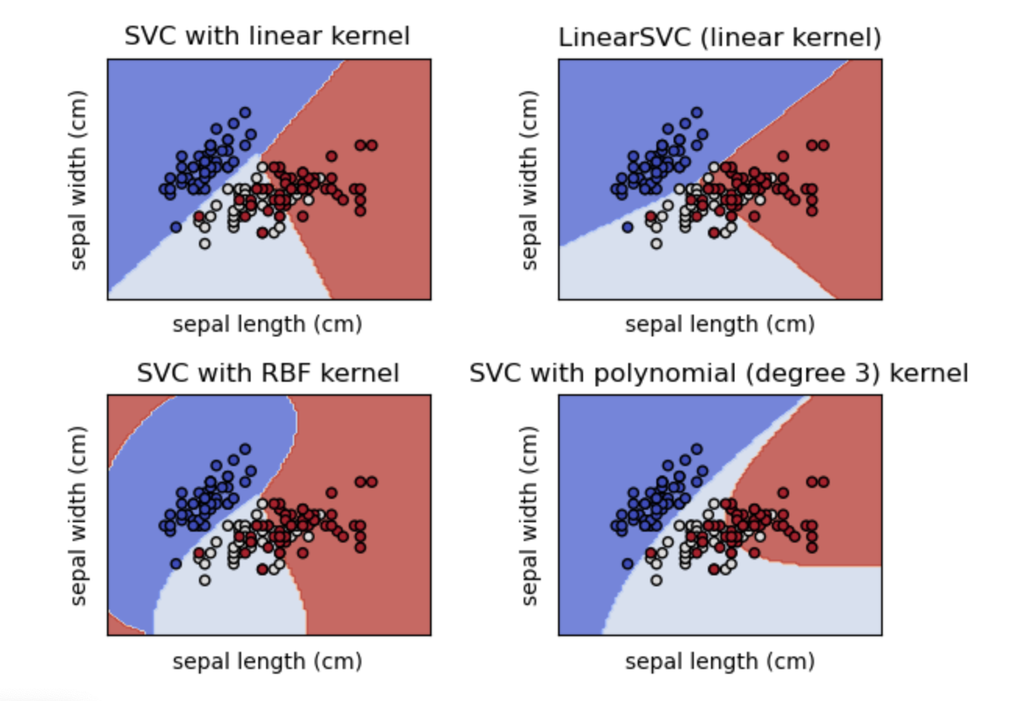

```python
Image(filename='img4.png')
```

#### 1. SVM with Linear Kernels ([Source](https://dataaspirant.com/svm-kernels/#t-1608054630727))

SVM linear model is the most basic type of kernel, usually one dimensional in nature. It proves to be the best function when there are lots of features. The linear kernel is mostly preferred for text-classification problems as most of these kinds of classification problems can be linearly separated. Linear kernel functions are faster than other functions.

Linear Kernel Formula:

F(x, xj) = sum( x.xj)

Here, x, xj represents the data you’re trying to classify.

```python
from sklearn.svm import SVC
from sklearn.metrics import classification_report, confusion_matrix

model = SVC(kernel='linear', C=0.5)
model = model.fit(x_train, y_train)

yp_train = model.predict(x_train)
yp_test = model.predict(x_test)
```

```
---------------------- TESTING DATA ----------------------
                   precision    recall  f1-score   support

Above Replacement       0.88      0.84      0.86       727
Below Replacement       0.75      0.80      0.77       420

         accuracy                           0.83      1147
        macro avg       0.81      0.82      0.82      1147
     weighted avg       0.83      0.83      0.83      1147

[[613 114]
 [ 84 336]]
---------------------- TRAINING DATA ----------------------
                   precision    recall  f1-score   support

Above Replacement       0.90      0.88      0.89      2925
Below Replacement       0.80      0.82      0.81      1663

         accuracy                           0.86      4588
        macro avg       0.85      0.85      0.85      4588
     weighted avg       0.86      0.86      0.86      4588

[[2584  341]
 [ 303 1360]]
```

```
<sklearn.metrics._plot.confusion_matrix.ConfusionMatrixDisplay at 0x7fab21fee7f0>
```

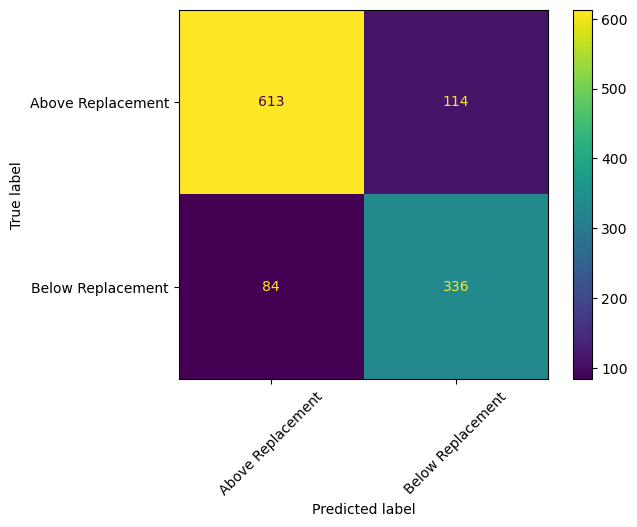

```python
from sklearn.metrics import ConfusionMatrixDisplay, classification_report

# TEST DATA
print('---------------------- TESTING DATA ----------------------')
print(classification_report(y_test, yp_test))
cm_test = confusion_matrix(y_test, yp_test)
print(cm_test)

# TRAIN DATA
print('---------------------- TRAINING DATA ----------------------')
train_rp = classification_report(y_train, yp_train)
print(train_rp)
cm_train = confusion_matrix(y_train, yp_train)
print(cm_train)

ConfusionMatrixDisplay(confusion_matrix=cm_test, display_labels=['Above Replacement', 'Below Replacement']).plot(xticks_rotation=45)
```

#### 2. SVM with Polynomial Kernels ([Source](https://dataaspirant.com/svm-kernels/#t-1608054630727))

SVM polynomial kernel is a more generalized representation of the linear kernel. It is not as preferred as other kernel functions as it is less efficient and accurate.

Polynomial Kernel Formula:

F(x, xj) = (x.xj+1)^d

```
---------------------- TESTING DATA ----------------------
                   precision    recall  f1-score   support

Above Replacement       0.76      0.96      0.85       727
Below Replacement       0.87      0.47      0.61       420

         accuracy                           0.78      1147
        macro avg       0.81      0.72      0.73      1147
     weighted avg       0.80      0.78      0.76      1147

[[696  31]
 [221 199]]
---------------------- TRAINING DATA ----------------------
                   precision    recall  f1-score   support

Above Replacement       0.76      0.97      0.85      2925
Below Replacement       0.90      0.46      0.61      1663

         accuracy                           0.79      4588
        macro avg       0.83      0.72      0.73      4588
     weighted avg       0.81      0.79      0.76      4588

[[2840   85]
 [ 896  767]]
```

```
<sklearn.metrics._plot.confusion_matrix.ConfusionMatrixDisplay at 0x7faaf27b9790>
```

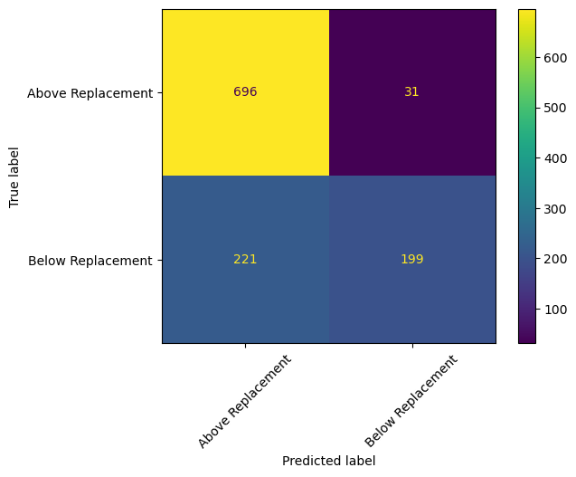

```python
model = SVC(kernel='poly', C=0.5, degree=2)
model = model.fit(x_train, y_train)

yp_train = model.predict(x_train)
yp_test = model.predict(x_test)

print('---------------------- TESTING DATA ----------------------')
print(classification_report(y_test, yp_test))
cm_test = confusion_matrix(y_test, yp_test)
print(cm_test)

# TRAIN DATA
print('---------------------- TRAINING DATA ----------------------')
train_rp = classification_report(y_train, yp_train)
print(train_rp)
cm_train = confusion_matrix(y_train, yp_train)
print(cm_train)

ConfusionMatrixDisplay(confusion_matrix=cm_test, display_labels=['Above Replacement', 'Below Replacement']).plot(xticks_rotation=45)
```

#### 3. SVM with Radial Basis Function (RBF) Kernels ([Source](https://dataaspirant.com/svm-kernels/#t-1608054630727))

SVM with RBF is one of the most preferred and used kernel functions in svm. It is usually chosen for non-linear data. It helps to make proper separation when there is no prior knowledge of data.

Gaussian Radial Basis Formula:

F(x, xj) = exp(-gamma * ||x - xj||^2)

The value of gamma varies from 0 to 1. You have to manually provide the value of gamma in the code. The most preferred value for gamma is 0.1.

```
---------------------- TESTING DATA ----------------------
                   precision    recall  f1-score   support

Above Replacement       0.88      0.87      0.87       727
Below Replacement       0.78      0.79      0.78       420

         accuracy                           0.84      1147
        macro avg       0.83      0.83      0.83      1147
     weighted avg       0.84      0.84      0.84      1147

[[632  95]
 [ 88 332]]
---------------------- TRAINING DATA ----------------------
                   precision    recall  f1-score   support

Above Replacement       0.89      0.90      0.90      2925
Below Replacement       0.82      0.81      0.81      1663

         accuracy                           0.87      4588
        macro avg       0.86      0.85      0.86      4588
     weighted avg       0.87      0.87      0.87      4588

[[2636  289]
 [ 323 1340]]
```

```
<sklearn.metrics._plot.confusion_matrix.ConfusionMatrixDisplay at 0x7faaf2831e50>
```

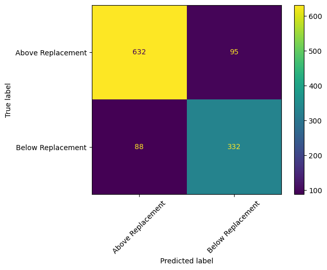

```python
model = SVC(kernel='rbf', C=0.5, degree=2)
model = model.fit(x_train, y_train)

yp_train = model.predict(x_train)
yp_test = model.predict(x_test)

# TEST DATA
print('---------------------- TESTING DATA ----------------------')
print(classification_report(y_test, yp_test))
cm_test = confusion_matrix(y_test, yp_test)
print(cm_test)

# TRAIN DATA
print('---------------------- TRAINING DATA ----------------------')
train_rp = classification_report(y_train, yp_train)
print(train_rp)
cm_train = confusion_matrix(y_train, yp_train)
print(cm_train)

ConfusionMatrixDisplay(confusion_matrix=cm_test, display_labels=['Above Replacement', 'Below Replacement']).plot(xticks_rotation=45)
```

#### 4. SVM with Sigmoid Kernels ([Source](https://dataaspirant.com/svm-kernels/#t-1608054630727))

SVM with sigmoid kernels is mostly preferred for neural networks. This kernel function is similar to a two-layer perceptron model of the neural network, which works as an activation function for neurons.

Sigmoid Kenel Function:

F(x, xj) = tanh(αxay + c)

```
---------------------- TESTING DATA ----------------------
                   precision    recall  f1-score   support

Above Replacement       0.81      0.80      0.80       727
Below Replacement       0.66      0.67      0.66       420

         accuracy                           0.75      1147
        macro avg       0.73      0.73      0.73      1147
     weighted avg       0.75      0.75      0.75      1147

[[583 144]
 [140 280]]
---------------------- TRAINING DATA ----------------------
                   precision    recall  f1-score   support

Above Replacement       0.84      0.84      0.84      2925
Below Replacement       0.72      0.72      0.72      1663

         accuracy                           0.80      4588
        macro avg       0.78      0.78      0.78      4588
     weighted avg       0.80      0.80      0.80      4588

[[2468  457]
 [ 462 1201]]
```

```
<sklearn.metrics._plot.confusion_matrix.ConfusionMatrixDisplay at 0x7fab21ff5e50>
```

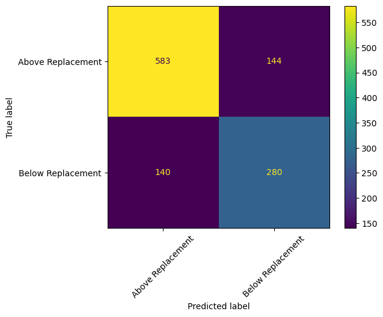

```python
model = SVC(kernel='sigmoid', C=0.5)
model = model.fit(x_train, y_train)

yp_train = model.predict(x_train)
yp_test = model.predict(x_test)

# TEST DATA
print('---------------------- TESTING DATA ----------------------')
print(classification_report(y_test, yp_test))
cm_test = confusion_matrix(y_test, yp_test)
print(cm_test)

# TRAIN DATA
print('---------------------- TRAINING DATA ----------------------')
train_rp = classification_report(y_train, yp_train)
print(train_rp)
cm_train = confusion_matrix(y_train, yp_train)
print(cm_train)

ConfusionMatrixDisplay(confusion_matrix=cm_test, display_labels=['Above Replacement', 'Below Replacement']).plot(xticks_rotation=45)
```

### Conclusion

Based on the classification reports above, we can see that the predictive performance of the Support Vector Machine (SVM) classifier on the testing data was relatively satisfying. Among all the kernels used for the SVM, RBF kernels and linear kernels have the best predictions with the highest accuracies. Overall speaking, SVM models fit the fertility rate dataset ideally.